# Risk Factor Analysis

## Outcome Variable

**Outcome Variable:** haz

## Predictor Variables

**Intervention Variable:** hhwealth_quart

**Adjustment Set:**

- arm
- sex
- W_mage
- meducyrs
- feducyrs
- W_gagebrth
- W_birthwt
- W_birthlen
- W_nchldlt5
- W_parity
- delta_W_mage
- delta_meducyrs
- delta_feducyrs
- delta_W_gagebrth
- delta_W_birthwt
- delta_W_birthlen
- delta_W_nchldlt5
- delta_W_parity

## Stratifying Variables

The analysis was stratified on these variable(s):

- agecat
- studyid
- country

## Data Summary

| agecat | studyid | country | hhwealth_quart | n_cell | n | outcome_variable |
| --- | --- | --- | --- | --- | --- | --- |
| Birth | ki0047075b-MAL-ED | BANGLADESH | Wealth Q4 | 56 | 213 | haz |
| Birth | ki0047075b-MAL-ED | BANGLADESH | Wealth Q1 | 52 | 213 | haz |
| Birth | ki0047075b-MAL-ED | BANGLADESH | Wealth Q2 | 51 | 213 | haz |
| Birth | ki0047075b-MAL-ED | BANGLADESH | Wealth Q3 | 54 | 213 | haz |
| Birth | ki0047075b-MAL-ED | BRAZIL | Wealth Q4 | 11 | 60 | haz |
| Birth | ki0047075b-MAL-ED | BRAZIL | Wealth Q1 | 21 | 60 | haz |
| Birth | ki0047075b-MAL-ED | BRAZIL | Wealth Q2 | 17 | 60 | haz |
| Birth | ki0047075b-MAL-ED | BRAZIL | Wealth Q3 | 11 | 60 | haz |
| Birth | ki0047075b-MAL-ED | INDIA | Wealth Q4 | 8 | 41 | haz |
| Birth | ki0047075b-MAL-ED | INDIA | Wealth Q1 | 14 | 41 | haz |
| Birth | ki0047075b-MAL-ED | INDIA | Wealth Q2 | 9 | 41 | haz |
| Birth | ki0047075b-MAL-ED | INDIA | Wealth Q3 | 10 | 41 | haz |
| Birth | ki0047075b-MAL-ED | NEPAL | Wealth Q4 | 6 | 26 | haz |
| Birth | ki0047075b-MAL-ED | NEPAL | Wealth Q1 | 9 | 26 | haz |
| Birth | ki0047075b-MAL-ED | NEPAL | Wealth Q2 | 3 | 26 | haz |
| Birth | ki0047075b-MAL-ED | NEPAL | Wealth Q3 | 8 | 26 | haz |
| Birth | ki0047075b-MAL-ED | PERU | Wealth Q4 | 54 | 215 | haz |
| Birth | ki0047075b-MAL-ED | PERU | Wealth Q1 | 55 | 215 | haz |
| Birth | ki0047075b-MAL-ED | PERU | Wealth Q2 | 54 | 215 | haz |
| Birth | ki0047075b-MAL-ED | PERU | Wealth Q3 | 52 | 215 | haz |
| Birth | ki0047075b-MAL-ED | SOUTH AFRICA | Wealth Q4 | 17 | 96 | haz |
| Birth | ki0047075b-MAL-ED | SOUTH AFRICA | Wealth Q1 | 27 | 96 | haz |
| Birth | ki0047075b-MAL-ED | SOUTH AFRICA | Wealth Q2 | 24 | 96 | haz |
| Birth | ki0047075b-MAL-ED | SOUTH AFRICA | Wealth Q3 | 28 | 96 | haz |
| Birth | ki0047075b-MAL-ED | TANZANIA, UNITED REPUBLIC OF | Wealth Q4 | 26 | 120 | haz |
| Birth | ki0047075b-MAL-ED | TANZANIA, UNITED REPUBLIC OF | Wealth Q1 | 28 | 120 | haz |
| Birth | ki0047075b-MAL-ED | TANZANIA, UNITED REPUBLIC OF | Wealth Q2 | 32 | 120 | haz |
| Birth | ki0047075b-MAL-ED | TANZANIA, UNITED REPUBLIC OF | Wealth Q3 | 34 | 120 | haz |
| Birth | ki1000108-CMC-V-BCS-2002 | INDIA | Wealth Q4 | 32 | 92 | haz |
| Birth | ki1000108-CMC-V-BCS-2002 | INDIA | Wealth Q1 | 15 | 92 | haz |

[output cut: 178 more lines]

The following strata were considered:

- agecat: 24 months, studyid: ki0047075b-MAL-ED, country: BANGLADESH
- agecat: 24 months, studyid: ki0047075b-MAL-ED, country: BRAZIL
- agecat: 24 months, studyid: ki0047075b-MAL-ED, country: INDIA
- agecat: 24 months, studyid: ki0047075b-MAL-ED, country: NEPAL
- agecat: 24 months, studyid: ki0047075b-MAL-ED, country: PERU
- agecat: 24 months, studyid: ki0047075b-MAL-ED, country: SOUTH AFRICA
- agecat: 24 months, studyid: ki0047075b-MAL-ED, country: TANZANIA, UNITED REPUBLIC OF
- agecat: 24 months, studyid: ki1000108-CMC-V-BCS-2002, country: INDIA
- agecat: 24 months, studyid: ki1000108-IRC, country: INDIA
- agecat: 24 months, studyid: ki1017093b-PROVIDE, country: BANGLADESH
- agecat: 24 months, studyid: ki1066203-TanzaniaChild2, country: TANZANIA, UNITED REPUBLIC OF
- agecat: 24 months, studyid: ki1113344-GMS-Nepal, country: NEPAL
- agecat: 24 months, studyid: ki1114097-CONTENT, country: PERU
- agecat: 24 months, studyid: ki1135781-COHORTS, country: GUATEMALA
- agecat: 24 months, studyid: ki1135781-COHORTS, country: PHILIPPINES
- agecat: 24 months, studyid: ki1148112-LCNI-5, country: MALAWI
- agecat: 24 months, studyid: kiGH5241-JiVitA-3, country: BANGLADESH
- agecat: 24 months, studyid: kiGH5241-JiVitA-4, country: BANGLADESH
- agecat: 6 months, studyid: ki0047075b-MAL-ED, country: BANGLADESH
- agecat: 6 months, studyid: ki0047075b-MAL-ED, country: BRAZIL
- agecat: 6 months, studyid: ki0047075b-MAL-ED, country: INDIA
- agecat: 6 months, studyid: ki0047075b-MAL-ED, country: NEPAL
- agecat: 6 months, studyid: ki0047075b-MAL-ED, country: PERU
- agecat: 6 months, studyid: ki0047075b-MAL-ED, country: SOUTH AFRICA
- agecat: 6 months, studyid: ki0047075b-MAL-ED, country: TANZANIA, UNITED REPUBLIC OF
- agecat: 6 months, studyid: ki1000108-CMC-V-BCS-2002, country: INDIA
- agecat: 6 months, studyid: ki1000108-IRC, country: INDIA
- agecat: 6 months, studyid: ki1017093b-PROVIDE, country: BANGLADESH
- agecat: 6 months, studyid: ki1066203-TanzaniaChild2, country: TANZANIA, UNITED REPUBLIC OF
- agecat: 6 months, studyid: ki1113344-GMS-Nepal, country: NEPAL
- agecat: 6 months, studyid: ki1114097-CONTENT, country: PERU
- agecat: 6 months, studyid: ki1135781-COHORTS, country: GUATEMALA
- agecat: 6 months, studyid: ki1135781-COHORTS, country: PHILIPPINES
- agecat: 6 months, studyid: ki1148112-LCNI-5, country: MALAWI
- agecat: 6 months, studyid: kiGH5241-JiVitA-3, country: BANGLADESH
- agecat: 6 months, studyid: kiGH5241-JiVitA-4, country: BANGLADESH
- agecat: Birth, studyid: ki0047075b-MAL-ED, country: BANGLADESH
- agecat: Birth, studyid: ki0047075b-MAL-ED, country: BRAZIL
- agecat: Birth, studyid: ki0047075b-MAL-ED, country: INDIA
- agecat: Birth, studyid: ki0047075b-MAL-ED, country: NEPAL
- agecat: Birth, studyid: ki0047075b-MAL-ED, country: PERU
- agecat: Birth, studyid: ki0047075b-MAL-ED, country: SOUTH AFRICA
- agecat: Birth, studyid: ki0047075b-MAL-ED, country: TANZANIA, UNITED REPUBLIC OF
- agecat: Birth, studyid: ki1000108-CMC-V-BCS-2002, country: INDIA
- agecat: Birth, studyid: ki1000108-IRC, country: INDIA
- agecat: Birth, studyid: ki1017093b-PROVIDE, country: BANGLADESH
- agecat: Birth, studyid: ki1113344-GMS-Nepal, country: NEPAL
- agecat: Birth, studyid: ki1114097-CONTENT, country: PERU
- agecat: Birth, studyid: ki1135781-COHORTS, country: GUATEMALA
- agecat: Birth, studyid: ki1135781-COHORTS, country: PHILIPPINES
- agecat: Birth, studyid: kiGH5241-JiVitA-3, country: BANGLADESH
- agecat: Birth, studyid: kiGH5241-JiVitA-4, country: BANGLADESH

### Dropped Strata

Some strata were dropped due to rare outcomes:

- agecat: Birth, studyid: ki0047075b-MAL-ED, country: NEPAL
- agecat: Birth, studyid: ki1114097-CONTENT, country: PERU
- agecat: 24 months, studyid: ki1066203-TanzaniaChild2, country: TANZANIA, UNITED REPUBLIC OF

## Methods Detail

We’re interested in the causal parameters $E[Y_a]$ for all values of $a \in \mathcal{A}$. These parameters represent the mean outcome if, possibly contrary to fact, we intervened to set all units to have $A=a$. Under the randomization and positivity assumptions, these are identified by the statistical parameters $\psi_a=E_W[E_{Y|A,W}(Y|A=a,W)]$. In addition, we’re interested in the mean of $Y$, $E[Y]$ under no intervention (the observed mean). We will estimate these parameters by using SuperLearner to fit the relevant likelihood factors – $E_{Y|A,W}(Y|A=a,W)$ and $p(A=a|W)$, and then updating our likelihood fit using a joint TMLE.

For unadjusted analyses ($W=\{\}$), initial likelihoods were estimated using Lrnr_glm to estimate the simple $E(Y|A)$ and Lrnr_mean to estimate $p(A)$. For adjusted analyses, a small library containing Lrnr_glmnet, Lrnr_xgboost, and Lrnr_mean was used.

Having estimated these parameters, we will then use the delta method to estimate relative risks and attributable risks relative to a prespecified baseline level of $A$.

# Results Detail

## Results Plots

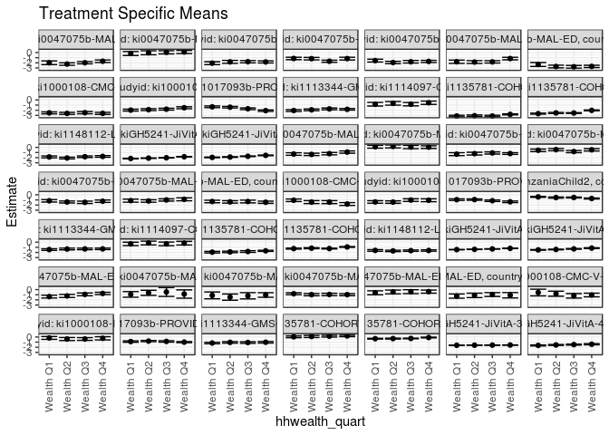

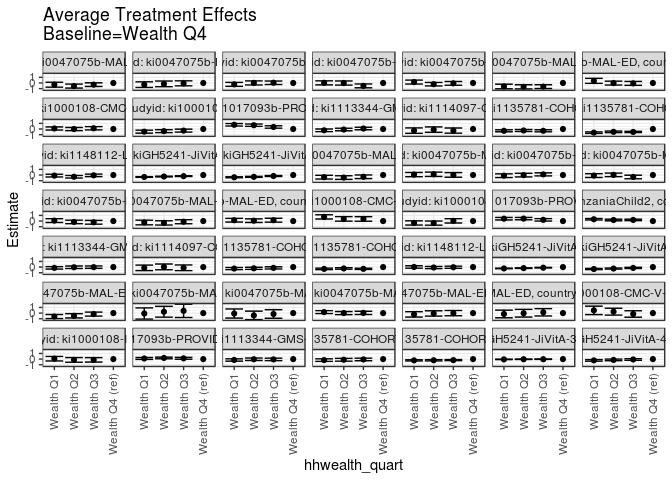

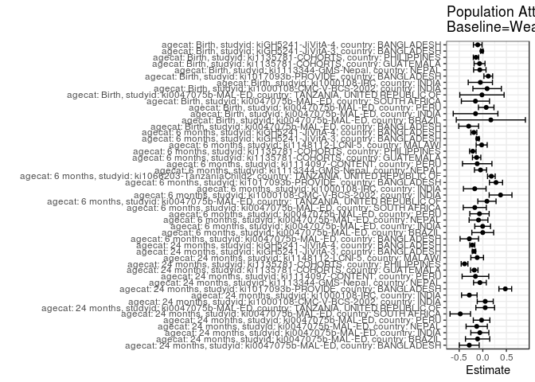

## Results Table

### Parameter: TSM

| agecat | studyid | country | intervention_level | baseline_level | estimate | ci_lower | ci_upper |
| --- | --- | --- | --- | --- | --- | --- | --- |
| Birth | ki0047075b-MAL-ED | BANGLADESH | Wealth Q4 | NA | -0.7539514 | -0.9821335 | -0.5257693 |
| Birth | ki0047075b-MAL-ED | BANGLADESH | Wealth Q1 | NA | -1.3627096 | -1.6375680 | -1.0878512 |
| Birth | ki0047075b-MAL-ED | BANGLADESH | Wealth Q2 | NA | -1.2325851 | -1.5323021 | -0.9328680 |
| Birth | ki0047075b-MAL-ED | BANGLADESH | Wealth Q3 | NA | -0.9331235 | -1.2036537 | -0.6625932 |
| Birth | ki0047075b-MAL-ED | BRAZIL | Wealth Q4 | NA | -0.8670097 | -1.6787803 | -0.0552391 |
| Birth | ki0047075b-MAL-ED | BRAZIL | Wealth Q1 | NA | -0.9370014 | -1.4861648 | -0.3878381 |
| Birth | ki0047075b-MAL-ED | BRAZIL | Wealth Q2 | NA | -0.6319867 | -1.1266517 | -0.1373217 |
| Birth | ki0047075b-MAL-ED | BRAZIL | Wealth Q3 | NA | -0.4703236 | -1.3302580 | 0.3896107 |
| Birth | ki0047075b-MAL-ED | INDIA | Wealth Q4 | NA | -1.0537500 | -1.5024873 | -0.6050127 |
| Birth | ki0047075b-MAL-ED | INDIA | Wealth Q1 | NA | -1.1307143 | -1.7957911 | -0.4656374 |
| Birth | ki0047075b-MAL-ED | INDIA | Wealth Q2 | NA | -1.4622222 | -2.0687425 | -0.8557019 |
| Birth | ki0047075b-MAL-ED | INDIA | Wealth Q3 | NA | -1.2070000 | -1.8208171 | -0.5931829 |
| Birth | ki0047075b-MAL-ED | PERU | Wealth Q4 | NA | -0.9865041 | -1.1849904 | -0.7880178 |
| Birth | ki0047075b-MAL-ED | PERU | Wealth Q1 | NA | -0.8104432 | -1.0012928 | -0.6195936 |
| Birth | ki0047075b-MAL-ED | PERU | Wealth Q2 | NA | -0.9842591 | -1.1994310 | -0.7690871 |
| Birth | ki0047075b-MAL-ED | PERU | Wealth Q3 | NA | -0.9510101 | -1.1838092 | -0.7182110 |
| Birth | ki0047075b-MAL-ED | SOUTH AFRICA | Wealth Q4 | NA | -0.3963245 | -0.6996852 | -0.0929638 |
| Birth | ki0047075b-MAL-ED | SOUTH AFRICA | Wealth Q1 | NA | -0.6227636 | -1.0115940 | -0.2339333 |
| Birth | ki0047075b-MAL-ED | SOUTH AFRICA | Wealth Q2 | NA | -0.4608120 | -0.8283936 | -0.0932304 |
| Birth | ki0047075b-MAL-ED | SOUTH AFRICA | Wealth Q3 | NA | -0.4033490 | -0.7782163 | -0.0284817 |
| Birth | ki0047075b-MAL-ED | TANZANIA, UNITED REPUBLIC OF | Wealth Q4 | NA | -1.1046856 | -1.6257278 | -0.5836433 |
| Birth | ki0047075b-MAL-ED | TANZANIA, UNITED REPUBLIC OF | Wealth Q1 | NA | -1.2610897 | -1.6751871 | -0.8469922 |
| Birth | ki0047075b-MAL-ED | TANZANIA, UNITED REPUBLIC OF | Wealth Q2 | NA | -1.1285348 | -1.5611901 | -0.6958795 |
| Birth | ki0047075b-MAL-ED | TANZANIA, UNITED REPUBLIC OF | Wealth Q3 | NA | -0.9643818 | -1.3390956 | -0.5896681 |
| Birth | ki1000108-CMC-V-BCS-2002 | INDIA | Wealth Q4 | NA | -1.0534276 | -1.4092057 | -0.6976496 |
| Birth | ki1000108-CMC-V-BCS-2002 | INDIA | Wealth Q1 | NA | -0.5731294 | -1.2295836 | 0.0833248 |
| Birth | ki1000108-CMC-V-BCS-2002 | INDIA | Wealth Q2 | NA | -0.7992407 | -1.2908688 | -0.3076126 |
| Birth | ki1000108-CMC-V-BCS-2002 | INDIA | Wealth Q3 | NA | -1.2128699 | -1.6528129 | -0.7729269 |
| Birth | ki1000108-IRC | INDIA | Wealth Q4 | NA | -0.2560548 | -0.5721090 | 0.0599994 |
| Birth | ki1000108-IRC | INDIA | Wealth Q1 | NA | -0.1810651 | -0.4585708 | 0.0964405 |

[output cut: 166 more lines]

### Parameter: E(Y)

| agecat | studyid | country | intervention_level | baseline_level | estimate | ci_lower | ci_upper |
| --- | --- | --- | --- | --- | --- | --- | --- |
| Birth | ki0047075b-MAL-ED | BANGLADESH | NA | NA | -1.0530516 | -1.1896058 | -0.9164975 |
| Birth | ki0047075b-MAL-ED | BRAZIL | NA | NA | -0.6963333 | -0.9881882 | -0.4044785 |
| Birth | ki0047075b-MAL-ED | INDIA | NA | NA | -1.2070732 | -1.5254820 | -0.8886644 |
| Birth | ki0047075b-MAL-ED | PERU | NA | NA | -0.9141395 | -1.0364098 | -0.7918693 |
| Birth | ki0047075b-MAL-ED | SOUTH AFRICA | NA | NA | -0.5523958 | -0.7550074 | -0.3497843 |
| Birth | ki0047075b-MAL-ED | TANZANIA, UNITED REPUBLIC OF | NA | NA | -1.1225000 | -1.3335666 | -0.9114334 |
| Birth | ki1000108-CMC-V-BCS-2002 | INDIA | NA | NA | -0.9611957 | -1.1776967 | -0.7446946 |
| Birth | ki1000108-IRC | INDIA | NA | NA | -0.3080412 | -0.4687931 | -0.1472894 |
| Birth | ki1017093b-PROVIDE | BANGLADESH | NA | NA | -0.8851020 | -0.9601332 | -0.8100709 |
| Birth | ki1113344-GMS-Nepal | NEPAL | NA | NA | -1.0851580 | -1.1651811 | -1.0051350 |
| Birth | ki1135781-COHORTS | GUATEMALA | NA | NA | 0.1452941 | 0.0610109 | 0.2295774 |
| Birth | ki1135781-COHORTS | PHILIPPINES | NA | NA | -0.2491505 | -0.2881717 | -0.2101294 |
| Birth | kiGH5241-JiVitA-3 | BANGLADESH | NA | NA | -1.5897094 | -1.6089856 | -1.5704331 |
| Birth | kiGH5241-JiVitA-4 | BANGLADESH | NA | NA | -1.5236135 | -1.5727559 | -1.4744711 |
| 6 months | ki0047075b-MAL-ED | BANGLADESH | NA | NA | -1.2026806 | -1.3203025 | -1.0850586 |
| 6 months | ki0047075b-MAL-ED | BRAZIL | NA | NA | 0.0475758 | -0.0963508 | 0.1915023 |
| 6 months | ki0047075b-MAL-ED | INDIA | NA | NA | -1.2070638 | -1.3255909 | -1.0885368 |
| 6 months | ki0047075b-MAL-ED | NEPAL | NA | NA | -0.5615819 | -0.6741832 | -0.4489807 |
| 6 months | ki0047075b-MAL-ED | PERU | NA | NA | -1.3248549 | -1.4336721 | -1.2160378 |
| 6 months | ki0047075b-MAL-ED | SOUTH AFRICA | NA | NA | -1.0547925 | -1.1843544 | -0.9252306 |
| 6 months | ki0047075b-MAL-ED | TANZANIA, UNITED REPUBLIC OF | NA | NA | -1.3687449 | -1.4907629 | -1.2467270 |
| 6 months | ki1000108-CMC-V-BCS-2002 | INDIA | NA | NA | -1.4234508 | -1.5645974 | -1.2823042 |
| 6 months | ki1000108-IRC | INDIA | NA | NA | -1.2344062 | -1.3658524 | -1.1029600 |
| 6 months | ki1017093b-PROVIDE | BANGLADESH | NA | NA | -1.0916915 | -1.1661176 | -1.0172654 |
| 6 months | ki1066203-TanzaniaChild2 | TANZANIA, UNITED REPUBLIC OF | NA | NA | -0.5442232 | -0.5932373 | -0.4952090 |
| 6 months | ki1113344-GMS-Nepal | NEPAL | NA | NA | -1.3508392 | -1.4290633 | -1.2726152 |
| 6 months | ki1114097-CONTENT | PERU | NA | NA | -0.3139217 | -0.4868486 | -0.1409948 |
| 6 months | ki1135781-COHORTS | GUATEMALA | NA | NA | -1.8112324 | -1.8807284 | -1.7417365 |
| 6 months | ki1135781-COHORTS | PHILIPPINES | NA | NA | -1.1405724 | -1.1824954 | -1.0986493 |
| 6 months | ki1148112-LCNI-5 | MALAWI | NA | NA | -1.6426961 | -1.7120603 | -1.5733318 |
| 6 months | kiGH5241-JiVitA-3 | BANGLADESH | NA | NA | -1.3132090 | -1.3363486 | -1.2900693 |
| 6 months | kiGH5241-JiVitA-4 | BANGLADESH | NA | NA | -1.3440477 | -1.3813060 | -1.3067894 |
| 24 months | ki0047075b-MAL-ED | BANGLADESH | NA | NA | -1.9783962 | -2.1050210 | -1.8517715 |
| 24 months | ki0047075b-MAL-ED | BRAZIL | NA | NA | 0.0061144 | -0.1625850 | 0.1748138 |
| 24 months | ki0047075b-MAL-ED | INDIA | NA | NA | -1.8861894 | -2.0110006 | -1.7613783 |
| 24 months | ki0047075b-MAL-ED | NEPAL | NA | NA | -1.3075877 | -1.4270718 | -1.1881037 |
| 24 months | ki0047075b-MAL-ED | PERU | NA | NA | -1.7524710 | -1.8736426 | -1.6312994 |
| 24 months | ki0047075b-MAL-ED | SOUTH AFRICA | NA | NA | -1.6450595 | -1.7797240 | -1.5103950 |
| 24 months | ki0047075b-MAL-ED | TANZANIA, UNITED REPUBLIC OF | NA | NA | -2.6455607 | -2.7807256 | -2.5103959 |
| 24 months | ki1000108-CMC-V-BCS-2002 | INDIA | NA | NA | -2.5588679 | -2.6583730 | -2.4593629 |
| 24 months | ki1000108-IRC | INDIA | NA | NA | -1.7987775 | -1.8923914 | -1.7051636 |
| 24 months | ki1017093b-PROVIDE | BANGLADESH | NA | NA | -1.6024221 | -1.6857420 | -1.5191023 |
| 24 months | ki1113344-GMS-Nepal | NEPAL | NA | NA | -1.8874180 | -1.9728588 | -1.8019773 |
| 24 months | ki1114097-CONTENT | PERU | NA | NA | -0.6962195 | -0.8674103 | -0.5250287 |
| 24 months | ki1135781-COHORTS | GUATEMALA | NA | NA | -2.9893430 | -3.0546993 | -2.9239867 |
| 24 months | ki1135781-COHORTS | PHILIPPINES | NA | NA | -2.4141145 | -2.4590818 | -2.3691473 |
| 24 months | ki1148112-LCNI-5 | MALAWI | NA | NA | -1.8822648 | -1.9637218 | -1.8008078 |
| 24 months | kiGH5241-JiVitA-3 | BANGLADESH | NA | NA | -2.0135591 | -2.0412422 | -1.9858759 |
| 24 months | kiGH5241-JiVitA-4 | BANGLADESH | NA | NA | -1.7803708 | -1.8158650 | -1.7448765 |

### Parameter: ATE

| agecat | studyid | country | intervention_level | baseline_level | estimate | ci_lower | ci_upper |
| --- | --- | --- | --- | --- | --- | --- | --- |
| Birth | ki0047075b-MAL-ED | BANGLADESH | Wealth Q4 | Wealth Q4 | 0.0000000 | 0.0000000 | 0.0000000 |
| Birth | ki0047075b-MAL-ED | BANGLADESH | Wealth Q1 | Wealth Q4 | -0.6087582 | -0.9662782 | -0.2512382 |
| Birth | ki0047075b-MAL-ED | BANGLADESH | Wealth Q2 | Wealth Q4 | -0.4786337 | -0.8570508 | -0.1002166 |
| Birth | ki0047075b-MAL-ED | BANGLADESH | Wealth Q3 | Wealth Q4 | -0.1791721 | -0.5341078 | 0.1757636 |
| Birth | ki0047075b-MAL-ED | BRAZIL | Wealth Q4 | Wealth Q4 | 0.0000000 | 0.0000000 | 0.0000000 |
| Birth | ki0047075b-MAL-ED | BRAZIL | Wealth Q1 | Wealth Q4 | -0.0699917 | -1.0604291 | 0.9204457 |
| Birth | ki0047075b-MAL-ED | BRAZIL | Wealth Q2 | Wealth Q4 | 0.2350230 | -0.7227888 | 1.1928349 |
| Birth | ki0047075b-MAL-ED | BRAZIL | Wealth Q3 | Wealth Q4 | 0.3966861 | -0.7797229 | 1.5730951 |
| Birth | ki0047075b-MAL-ED | INDIA | Wealth Q4 | Wealth Q4 | 0.0000000 | 0.0000000 | 0.0000000 |
| Birth | ki0047075b-MAL-ED | INDIA | Wealth Q1 | Wealth Q4 | -0.0769643 | -0.8792687 | 0.7253402 |
| Birth | ki0047075b-MAL-ED | INDIA | Wealth Q2 | Wealth Q4 | -0.4084722 | -1.1629469 | 0.3460025 |
| Birth | ki0047075b-MAL-ED | INDIA | Wealth Q3 | Wealth Q4 | -0.1532500 | -0.9136030 | 0.6071030 |
| Birth | ki0047075b-MAL-ED | PERU | Wealth Q4 | Wealth Q4 | 0.0000000 | 0.0000000 | 0.0000000 |
| Birth | ki0047075b-MAL-ED | PERU | Wealth Q1 | Wealth Q4 | 0.1760609 | -0.0819562 | 0.4340781 |
| Birth | ki0047075b-MAL-ED | PERU | Wealth Q2 | Wealth Q4 | 0.0022450 | -0.2725121 | 0.2770021 |
| Birth | ki0047075b-MAL-ED | PERU | Wealth Q3 | Wealth Q4 | 0.0354940 | -0.2504073 | 0.3213953 |
| Birth | ki0047075b-MAL-ED | SOUTH AFRICA | Wealth Q4 | Wealth Q4 | 0.0000000 | 0.0000000 | 0.0000000 |
| Birth | ki0047075b-MAL-ED | SOUTH AFRICA | Wealth Q1 | Wealth Q4 | -0.2264391 | -0.7024199 | 0.2495416 |
| Birth | ki0047075b-MAL-ED | SOUTH AFRICA | Wealth Q2 | Wealth Q4 | -0.0644875 | -0.5332146 | 0.4042397 |
| Birth | ki0047075b-MAL-ED | SOUTH AFRICA | Wealth Q3 | Wealth Q4 | -0.0070245 | -0.4701403 | 0.4560913 |
| Birth | ki0047075b-MAL-ED | TANZANIA, UNITED REPUBLIC OF | Wealth Q4 | Wealth Q4 | 0.0000000 | 0.0000000 | 0.0000000 |
| Birth | ki0047075b-MAL-ED | TANZANIA, UNITED REPUBLIC OF | Wealth Q1 | Wealth Q4 | -0.1564041 | -0.8342142 | 0.5214059 |
| Birth | ki0047075b-MAL-ED | TANZANIA, UNITED REPUBLIC OF | Wealth Q2 | Wealth Q4 | -0.0238493 | -0.7043372 | 0.6566387 |
| Birth | ki0047075b-MAL-ED | TANZANIA, UNITED REPUBLIC OF | Wealth Q3 | Wealth Q4 | 0.1403037 | -0.5056543 | 0.7862617 |
| Birth | ki1000108-CMC-V-BCS-2002 | INDIA | Wealth Q4 | Wealth Q4 | 0.0000000 | 0.0000000 | 0.0000000 |
| Birth | ki1000108-CMC-V-BCS-2002 | INDIA | Wealth Q1 | Wealth Q4 | 0.4802982 | -0.2677054 | 1.2283019 |
| Birth | ki1000108-CMC-V-BCS-2002 | INDIA | Wealth Q2 | Wealth Q4 | 0.2541869 | -0.3533252 | 0.8616990 |
| Birth | ki1000108-CMC-V-BCS-2002 | INDIA | Wealth Q3 | Wealth Q4 | -0.1594423 | -0.7269360 | 0.4080515 |
| Birth | ki1000108-IRC | INDIA | Wealth Q4 | Wealth Q4 | 0.0000000 | 0.0000000 | 0.0000000 |
| Birth | ki1000108-IRC | INDIA | Wealth Q1 | Wealth Q4 | 0.0749897 | -0.3254611 | 0.4754406 |

[output cut: 166 more lines]

### Parameter: PAR

| agecat | studyid | country | intervention_level | baseline_level | estimate | ci_lower | ci_upper |
| --- | --- | --- | --- | --- | --- | --- | --- |
| Birth | ki0047075b-MAL-ED | BANGLADESH | Wealth Q4 | NA | -0.2991003 | -0.5094147 | -0.0887858 |
| Birth | ki0047075b-MAL-ED | BRAZIL | Wealth Q4 | NA | 0.1706764 | -0.5624847 | 0.9038374 |
| Birth | ki0047075b-MAL-ED | INDIA | Wealth Q4 | NA | -0.1533232 | -0.6267868 | 0.3201405 |
| Birth | ki0047075b-MAL-ED | PERU | Wealth Q4 | NA | 0.0723645 | -0.0922303 | 0.2369594 |
| Birth | ki0047075b-MAL-ED | SOUTH AFRICA | Wealth Q4 | NA | -0.1560713 | -0.4543845 | 0.1422419 |
| Birth | ki0047075b-MAL-ED | TANZANIA, UNITED REPUBLIC OF | Wealth Q4 | NA | -0.0178144 | -0.4875490 | 0.4519201 |
| Birth | ki1000108-CMC-V-BCS-2002 | INDIA | Wealth Q4 | NA | 0.0922320 | -0.2095445 | 0.3940085 |
| Birth | ki1000108-IRC | INDIA | Wealth Q4 | NA | -0.0519864 | -0.3090546 | 0.2050818 |
| Birth | ki1017093b-PROVIDE | BANGLADESH | Wealth Q4 | NA | 0.1162328 | 0.0236534 | 0.2088121 |
| Birth | ki1113344-GMS-Nepal | NEPAL | Wealth Q4 | NA | -0.0629696 | -0.1943169 | 0.0683777 |
| Birth | ki1135781-COHORTS | GUATEMALA | Wealth Q4 | NA | -0.0687995 | -0.1845297 | 0.0469306 |
| Birth | ki1135781-COHORTS | PHILIPPINES | Wealth Q4 | NA | -0.1439239 | -0.2011853 | -0.0866624 |
| Birth | kiGH5241-JiVitA-3 | BANGLADESH | Wealth Q4 | NA | -0.0206469 | -0.0475497 | 0.0062559 |
| Birth | kiGH5241-JiVitA-4 | BANGLADESH | Wealth Q4 | NA | -0.1074465 | -0.1992346 | -0.0156584 |
| 6 months | ki0047075b-MAL-ED | BANGLADESH | Wealth Q4 | NA | -0.2858260 | -0.4815480 | -0.0901040 |
| 6 months | ki0047075b-MAL-ED | BRAZIL | Wealth Q4 | NA | -0.0007893 | -0.2317612 | 0.2301826 |
| 6 months | ki0047075b-MAL-ED | INDIA | Wealth Q4 | NA | -0.0027492 | -0.1697485 | 0.1642501 |
| 6 months | ki0047075b-MAL-ED | NEPAL | Wealth Q4 | NA | -0.0908337 | -0.2898164 | 0.1081491 |
| 6 months | ki0047075b-MAL-ED | PERU | Wealth Q4 | NA | -0.0703907 | -0.2753956 | 0.1346141 |
| 6 months | ki0047075b-MAL-ED | SOUTH AFRICA | Wealth Q4 | NA | -0.1695647 | -0.4143107 | 0.0751813 |
| 6 months | ki0047075b-MAL-ED | TANZANIA, UNITED REPUBLIC OF | Wealth Q4 | NA | 0.0879598 | -0.1051821 | 0.2811017 |
| 6 months | ki1000108-CMC-V-BCS-2002 | INDIA | Wealth Q4 | NA | 0.3767371 | 0.1349847 | 0.6184895 |
| 6 months | ki1000108-IRC | INDIA | Wealth Q4 | NA | -0.1704945 | -0.4103159 | 0.0693270 |
| 6 months | ki1017093b-PROVIDE | BANGLADESH | Wealth Q4 | NA | 0.2800270 | 0.1407504 | 0.4193036 |
| 6 months | ki1066203-TanzaniaChild2 | TANZANIA, UNITED REPUBLIC OF | Wealth Q4 | NA | 0.1817707 | 0.1007752 | 0.2627663 |
| 6 months | ki1113344-GMS-Nepal | NEPAL | Wealth Q4 | NA | -0.0484177 | -0.1769274 | 0.0800920 |
| 6 months | ki1114097-CONTENT | PERU | Wealth Q4 | NA | -0.1184652 | -0.4307313 | 0.1938009 |
| 6 months | ki1135781-COHORTS | GUATEMALA | Wealth Q4 | NA | -0.1306095 | -0.2189992 | -0.0422198 |
| 6 months | ki1135781-COHORTS | PHILIPPINES | Wealth Q4 | NA | -0.2117632 | -0.2805573 | -0.1429692 |
| 6 months | ki1148112-LCNI-5 | MALAWI | Wealth Q4 | NA | -0.0238170 | -0.1407806 | 0.0931465 |
| 6 months | kiGH5241-JiVitA-3 | BANGLADESH | Wealth Q4 | NA | -0.1071248 | -0.1375028 | -0.0767469 |
| 6 months | kiGH5241-JiVitA-4 | BANGLADESH | Wealth Q4 | NA | -0.1894791 | -0.2523809 | -0.1265772 |
| 24 months | ki0047075b-MAL-ED | BANGLADESH | Wealth Q4 | NA | -0.2873139 | -0.4981355 | -0.0764922 |
| 24 months | ki0047075b-MAL-ED | BRAZIL | Wealth Q4 | NA | -0.1101283 | -0.3674348 | 0.1471782 |
| 24 months | ki0047075b-MAL-ED | INDIA | Wealth Q4 | NA | -0.0626273 | -0.2535638 | 0.1283093 |
| 24 months | ki0047075b-MAL-ED | NEPAL | Wealth Q4 | NA | -0.1288716 | -0.3541260 | 0.0963827 |
| 24 months | ki0047075b-MAL-ED | PERU | Wealth Q4 | NA | -0.0256640 | -0.2013807 | 0.1500528 |
| 24 months | ki0047075b-MAL-ED | SOUTH AFRICA | Wealth Q4 | NA | -0.4777250 | -0.6947812 | -0.2606687 |
| 24 months | ki0047075b-MAL-ED | TANZANIA, UNITED REPUBLIC OF | Wealth Q4 | NA | 0.0514115 | -0.1469487 | 0.2497718 |
| 24 months | ki1000108-CMC-V-BCS-2002 | INDIA | Wealth Q4 | NA | 0.0517921 | -0.1179615 | 0.2215457 |
| 24 months | ki1000108-IRC | INDIA | Wealth Q4 | NA | -0.2858985 | -0.4501644 | -0.1216326 |
| 24 months | ki1017093b-PROVIDE | BANGLADESH | Wealth Q4 | NA | 0.4771430 | 0.3420870 | 0.6121989 |
| 24 months | ki1113344-GMS-Nepal | NEPAL | Wealth Q4 | NA | -0.0605969 | -0.1957013 | 0.0745075 |
| 24 months | ki1114097-CONTENT | PERU | Wealth Q4 | NA | -0.1559229 | -0.4385656 | 0.1267199 |
| 24 months | ki1135781-COHORTS | GUATEMALA | Wealth Q4 | NA | -0.1804276 | -0.2590778 | -0.1017774 |
| 24 months | ki1135781-COHORTS | PHILIPPINES | Wealth Q4 | NA | -0.3865932 | -0.4579314 | -0.3152549 |
| 24 months | ki1148112-LCNI-5 | MALAWI | Wealth Q4 | NA | -0.1191572 | -0.2533327 | 0.0150183 |
| 24 months | kiGH5241-JiVitA-3 | BANGLADESH | Wealth Q4 | NA | -0.1866011 | -0.2232221 | -0.1499801 |
| 24 months | kiGH5241-JiVitA-4 | BANGLADESH | Wealth Q4 | NA | -0.2229104 | -0.2766236 | -0.1691972 |